# MATH 4753: Exam 2: Help

Dr. Wayne Stewart

October 25, 2018

# Introduction

The second exam typically covers chapters 5-7 and will be no exception this time.

In case you are interested in how I made the graphs see the links below.

http://www.htmlwidgets.org/showcase_diagrammer.html http://rich-iannone.github.io/DiagrammeR/

[interactive chart not shown]

# Questions and pointed help

There will be some other possible questions – but here is a good start.

## Q1 Change of variable

Make sure you can use the change of variable formula. If I give you a density in $X$ which is defined over an area and a function $Y=\phi (X)$ then you should be able to give me the density in $Y$.

Prepare by doing examples.

$$f_Y(y)=f_X(\phi^{-1}(y))\left | \frac{d\phi^{-1}(y)}{dy}\right |$$

## Q2 Unbiased estimators

Make sure you can prove

$$E(S^2)=\sigma^2$$

This was done in class Friday 10-26-2018.

It is also proved in the book – please see notes or book.

Prepare by going through the proof by yourself without looking at notes and place comments after each line to prove you know what is happenning.

## Q3 MLE

Maximum likelihood. There are many facets to this!! See lab 10 and everything around this.

[interactive chart not shown]

Prepare by going through Lab 10 and my notes and the theoretical exercises MS page 300

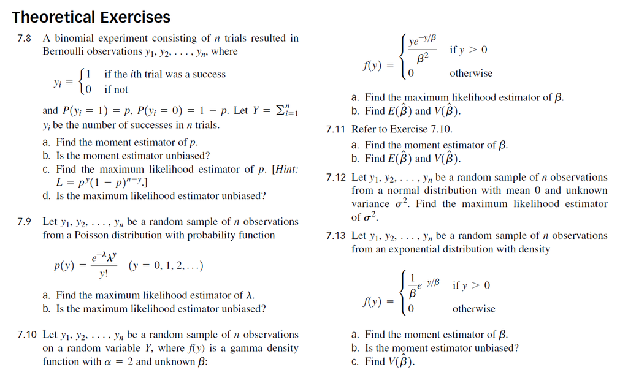

Theoretical Exercises

## Q4 Covariance

Make sure you can do basic double integrals. You will need to find the constant $c$ using one of the three ppties of a density.

This is often done in the context of a covariance.

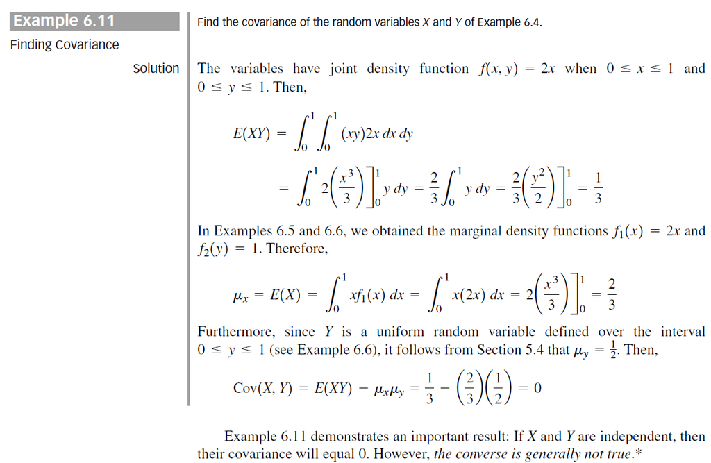

Example 6.11 page 251 MS

## Q5 Confidence Intervals

I have developed a number of CI’s in class. You should be able to prove some of them.

At least be able to prove the cases for a $\mu, \sigma^2$ and $p$. The last uses the central Limit theorem which is important.

$$\bar{Y}\pm t_{\alpha/2}\frac{s}{\sqrt{n}}$$
The quantile is calculated in R using the following code, $t_{\alpha/2}=\text{qt}(1-\alpha/2,n-1)$.

$$\left ( \frac{(n-1)S^2}{\chi^2_{\alpha/2}},\frac{(n-1)S^2}{\chi^2_{1-\alpha/2}} \right )$$

The Chisquare quantiles are calculated using the following:

$\chi^2_{\alpha/2}=\text{qchisq}(1-\alpha/2, n-1)$ and $\chi^2_{1-\alpha/2}=\text{qchisq}(\alpha/2, n-1)$

$$\hat{p}\pm z_{\alpha/2}\sqrt{\frac{\hat{p}\hat{q}}{n}}$$

The quantile $z_{\alpha/2}=\text{qnorm}(1-\alpha/2,0,1)$

## Q 6 Linear functions

Oh man!!

$$l=4Y_1 -2Y_2 +3Y_3$$
$$Y_i \sim N(\mu = 10, \sigma^2 =3)$$

Find $V(l)$ and find $E(l)$

Rock and Roll man!!